# Module 7: Cell-specific Co-expression Networks (NeighbourNet)

Single Cell Workshop

2026-04-28

## 1 Introduction

The previous two modules gave us a continuous view of cardiomyocyte maturation. Module 5 built Φ-Space scores: each cell received a score for how much it resembled fetal, young, middle and old reference phenotypes. Module 6 turned those scores into several pseudotime axes and saved a cardiomyocyte-only object for downstream analysis.

Here we ask a different question: as cardiomyocytes mature, do the relationships between genes change?

It is tempting to call this a **gene regulatory network** analysis, but that would overstate what single-cell RNA-seq alone can prove. A true GRN is directional and mechanistic: it says that one factor regulates another in a causal sense. Co-expression does not get us all the way there.

Instead, we will build a **cell-specific co-expression network**. This is a statistical scaffold: it tells us which transcription factors and target genes vary together in local neighbourhoods of cells. If the scaffold is well constructed, it can contain useful regulatory hypotheses, but the edges are still associations, not proof of causality.

We use **NeighbourNet** (NNet), a method for building noisy per-cell co-expression networks and then denoising them into a small number of recurring **meta-networks**. The method borrows strength from each cell’s nearest neighbours, computes a network for each cell, and then aggregates those networks with non-negative PCA so that the strongest recurring network patterns are visible.

### 1.1 What this module will do

We will:

- load the cardiomyocyte object from Module 6;
- convert it from `SingleCellExperiment` to `Seurat`, because NeighbourNet works on Seurat objects;
- use `PhiSpace::rankFeatures()` to choose maturation-associated target genes from the trajectory-free Φ-Space score `pt_phi_score`;
- run the NeighbourNet workflow on those target genes;
- find the meta-network whose cell scores correlate most strongly with `pt_phi_score`;
- visualise that maturation-associated meta-network.

We deliberately use `pt_phi_score`, not one of the slingshot or DPT pseudotimes. `pt_phi_score` is simply the adult-like Φ-Space score minus the fetal Φ-Space score, so it is a trajectory-free maturation baseline. That keeps this module focused on network rewiring rather than on the method comparison from Module 6.

### 1.2 Learning objectives

By the end of this module you will be able to:

- distinguish co-expression networks from causal gene regulatory networks;
- explain why NeighbourNet builds per-cell networks before aggregating them into meta-networks;
- select target genes associated with a continuous phenotype using `PhiSpace::rankFeatures()`;
- run the core NeighbourNet workflow on a Seurat object;
- interpret a meta-network figure without over-claiming causality.

## 2 Load Libraries and Module 6 Output

```r
library(SingleCellExperiment)
library(Seurat)
library(NeighbourNet)
library(PhiSpace)
library(ggplot2)
library(dplyr)
library(tibble)
library(patchwork)
library(RColorBrewer)
```

Module 6 saved the cardiomyocyte subset with expression, Φ-Space scores, UMAP coordinates, six pseudotime estimates, and the trajectory-free `pt_phi_score`.

```r
cm <- readRDS("../results/06_cm_pseudotime.rds")

cat("Assays:      ", paste(assayNames(cm), collapse = ", "), "\n")
```

```
## Assays:       counts, logcounts
```

```r
cat("reducedDims: ", paste(reducedDimNames(cm), collapse = ", "), "\n")
```

```
## reducedDims:  PhiSpace, PCA, UMAP
```

```r
cat("Cells:       ", ncol(cm), "\n")
```

```
## Cells:        5411
```

```r
cat("Genes:       ", nrow(cm), "\n")
```

```
## Genes:        15094
```

```r
cat("Groups:      ", paste(table(cm$group), collapse = ", "), "\n")
```

```
## Groups:       409, 4016, 986
```

```r
summary(cm$pt_phi_score)
```

```
##    Min. 1st Qu.  Median    Mean 3rd Qu.    Max.
## -1.1966 -0.8363 -0.7419 -0.4401  0.3216  0.8593
```

```r
results_dir <- "../results"
dir.create(results_dir, showWarnings = FALSE, recursive = TRUE)

n_targets <- 10
n_meta_networks <- 2
```

## 3 Convert to Seurat

NeighbourNet expects a Seurat object with normalised expression in the `data` layer. The scran `logcounts` from Module 5 are already suitable, so we do not run `NormalizeData()` again.

```r
stopifnot(all(c("counts", "logcounts") %in% assayNames(cm)))

seu <- as.Seurat(cm, counts = "counts", data = "logcounts")

seu$pt_phi_score <- cm$pt_phi_score
seu$group <- cm$group
seu$PhiCellType <- cm$PhiCellType
seu$PhiCellTypeBroad <- cm$PhiCellTypeBroad

cat("Seurat cells:", ncol(seu), "\n")
```

```
## Seurat cells: 5411
```

```r
cat("Seurat genes:", nrow(seu), "\n")
```

```
## Seurat genes: 15094
```

```r
head(seu@meta.data[, c("group", "PhiCellType", "pt_phi_score")])
```

|  | group | PhiCellType | pt_phi_score |
| --- | --- | --- | --- |
| AAACGAACAAACTCTG_f1 | fetal | Cardiomyocyte:Fetal_enriched_metabolic | -0.8182650 |
| AAACGAATCCGATAAC_f1 | fetal | Cardiomyocyte:Metabolic | -0.6362926 |
| AAAGAACGTCATACCA_f1 | fetal | Cardiomyocyte:Fetal_enriched_metabolic | -0.6920746 |
| AAAGGATTCTCGCTTG_f1 | fetal | Cardiomyocyte:Other | -0.7083411 |
| AAAGGGCGTAGGAAAG_f1 | fetal | Cardiomyocyte:Fetal_enriched_metabolic | -0.7925069 |
| AAAGGTAAGAGTGTTA_f1 | fetal | Cardiomyocyte:Other | -0.6458774 |

## 4 Select Maturation-associated Target Genes

NeighbourNet can use its built-in target-gene prior directly, but for a short workshop module we want the network to focus on the maturation axis. We therefore rank genes by their association with `pt_phi_score` and keep the top 10.

`rankFeatures()` fits a PLS model from expression to the continuous response and ranks genes by the absolute coefficient. Positive and negative coefficients are both useful: they mark genes associated with adult-like or fetal-like ends of the same maturation gradient.

```r
rank_res <- PhiSpace::rankFeatures(
    data       = cm,
    response   = cm$pt_phi_score,
    method     = "PLS",
    source     = "assay",
    assay_name = "logcounts",
    center     = TRUE,
    scale      = FALSE,
    seed       = 42
)

rank_tbl <- as_tibble(rank_res$feature_ranking)
score_col <- if ("importance_norm" %in% names(rank_tbl)) {
    "importance_norm"
} else {
    setdiff(names(rank_tbl), "feature")[1]
}

rank_tbl <- rank_tbl |>
    arrange(desc(.data[[score_col]]))

top_targets <- head(rank_tbl$feature, n_targets)
top_targets <- intersect(top_targets, rownames(seu))

cat("Top targets retained in Seurat object:", length(top_targets), "\n")
```

```
## Top targets retained in Seurat object: 10
```

```r
head(rank_tbl, 20)
```

| feature | importance | abs_importance |
| --- | --- | --- |
| NEAT1 | 0.008409071 | 0.008409071 |
| PDE3A | 0.007062143 | 0.007062143 |
| PXDNL | 0.004714502 | 0.004714502 |
| PRKG1 | 0.004492638 | 0.004492638 |
| MYOM2 | 0.004148116 | 0.004148116 |
| CD36 | 0.004065300 | 0.004065300 |
| ZBTB20 | 0.004042562 | 0.004042562 |
| SGCD | 0.003781671 | 0.003781671 |
| CCSER1 | 0.003706972 | 0.003706972 |
| RCAN2 | 0.003630395 | 0.003630395 |

[output cut: 10 more lines]

The top-ranked genes should look like cardiomyocyte maturation markers: contractile genes, metabolic genes, stress-response genes, and genes that track the fetal-to-adult shift in cell state. The exact list is less important than the principle: the target set defines the biological question asked of NeighbourNet. Here we keep only 10 target genes so the per-cell network cube is small enough to knit during the workshop.

## 5 Run NeighbourNet

The core workflow is:

1. resolve target and transcription-factor lists;
2. scale the selected genes and compute PCA;
3. build a k-nearest-neighbour graph in PC space;
4. set up local regressions from TFs to target genes;
5. run per-cell network regression;
6. aggregate the cell-specific networks into meta-networks.

This is the slowest chunk in the module, so we cache the Seurat object immediately after `build.meta.network()`.

```r
nnet_cache <- file.path(
    results_dir,
    sprintf("07_seu_nnet_%02dtargets.rds", n_targets)
)

if (file.exists(nnet_cache)) {
    seu <- readRDS(nnet_cache)
    message("Loaded cached NeighbourNet object from ", nnet_cache)
} else {
    # NeighbourNet 1.0.0's select.gene() currently references a hard-coded
    # object name internally, so we reproduce the small filtering step here.
    select_nnet_genes <- function(seurat_obj, targets, min.cells = 10) {
        gene_list <- NeighbourNet::gene.list
        genes_all <- rownames(seurat_obj)
        counts <- SeuratObject::LayerData(seurat_obj, layer = "counts")
        n_cell_expressed <- Matrix::rowSums(counts[genes_all, , drop = FALSE] > 0)
        genes_kept <- genes_all[n_cell_expressed > min.cells]

        tfs <- intersect(genes_kept, unique(gene_list$tfs))
        targets <- intersect(genes_kept, intersect(gene_list$targets, targets))

        list(
            tfs = tfs,
            targets = targets,
            bgs = character(0),
            genes = unique(c(tfs, targets))
        )
    }

    genes <- select_nnet_genes(seu, targets = top_targets, min.cells = 10)

    cat("Predictor TFs:", length(genes$tfs), "\n")
    cat("Target genes: ", length(genes$targets), "\n")
    cat("Total genes:  ", length(genes$genes), "\n")

    if (length(genes$targets) < 5) {
        warning("Fewer than five target genes survived filtering; ",
                "the network plots may be sparse.")
    }
    if (length(genes$genes) < 3) {
        stop("Too few genes survived NeighbourNet filtering.")
    }

    npcs <- min(50, length(genes$genes) - 1, ncol(seu) - 1)
    knn <- min(30, ncol(seu) - 1)

    seu <- prepare.seurat(seu, genes = genes$genes, npcs = npcs)
    seu <- prepare.graph(seu, knn = knn)
    seu <- prepare.reg(seu,
                       predictors = genes$tfs,
                       responses  = genes$targets)
    seu <- run.nn.reg(seu,
                      responses = genes$targets,
                      return.p.val = TRUE)
    seu <- build.meta.network(seu, n.net = n_meta_networks)

    seu@misc$Module7 <- list(
        feature_ranking = rank_tbl,
        top_targets = top_targets,
        n_targets = n_targets,
        n_meta_networks = n_meta_networks
    )

    saveRDS(seu, nnet_cache)
}
```

```r
nnet_mod <- Seurat::Misc(seu, "NNet.mod")
names(nnet_mod)
```

```
##  [1] "effect"        "p.val"         "meta.network"  "meta.response"
##  [5] "mus"           "sigmas"        "subsampled"    "smoothed"
##  [9] "pruned"        "gene.sets"     "cells"         "defaults"
## [13] "custom.y"      "w"
```

```r
names(nnet_mod$meta.network)
```

```
##  [1] "meta.network"  "p.val"         "pcs"           "pca.loadings"
##  [5] "pca.sd"        "npca.loadings" "npca.sd"       "scale"
##  [9] "non.neg"       "setting"
```

```r
dim(nnet_mod$meta.network$pcs)
```

```
## [1] 5411  100
```

```r
dim(nnet_mod$meta.network$meta.network)
```

```
## [1]   5 875   2
```

## 6 Meta-network Space

Before visualising any one network, we check whether the meta-network embedding carries the maturation signal. If the first few meta-networks separate fetal-like and adult-like cells, NeighbourNet has found co-expression programs that vary with maturation.

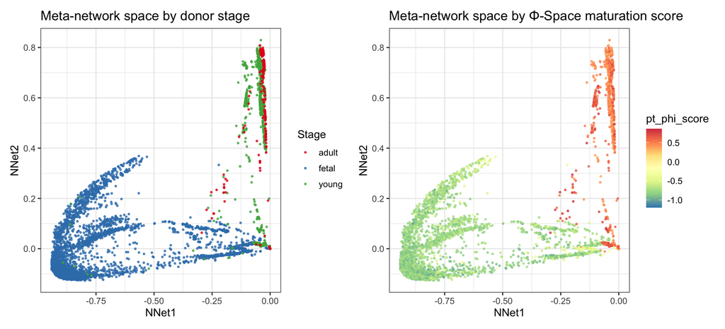

```r
meta_pcs <- nnet_mod$meta.network$pcs
if (is.null(rownames(meta_pcs))) {
    rownames(meta_pcs) <- colnames(seu)
}

pcs_df <- as.data.frame(meta_pcs[, 1:2, drop = FALSE])
colnames(pcs_df) <- c("NNet1", "NNet2")
pcs_df$cell <- rownames(pcs_df)

meta_df <- seu@meta.data[match(pcs_df$cell, rownames(seu@meta.data)), ]
pcs_df$group <- meta_df$group
pcs_df$pt_phi_score <- meta_df$pt_phi_score

p_stage <- ggplot(pcs_df, aes(NNet1, NNet2, colour = group)) +
    geom_point(size = 0.6, alpha = 0.75) +
    scale_colour_brewer(palette = "Set1") +
    labs(title = "Meta-network space by donor stage",
         colour = "Stage") +
    theme_bw(base_size = 12)

p_pt <- ggplot(pcs_df, aes(NNet1, NNet2, colour = pt_phi_score)) +
    geom_point(size = 0.6, alpha = 0.75) +
    scale_colour_distiller(palette = "Spectral", direction = -1) +
    labs(title = "Meta-network space by Φ-Space maturation score",
         colour = "pt_phi_score") +
    theme_bw(base_size = 12)

p_stage | p_pt
```

### 6.1 Meta-network scores on the PCA UMAP

Figure 3B of the NeighbourNet paper projects meta-network cell weights back onto a familiar expression UMAP. This is useful pedagogically: the meta-network embedding above tells us that cells differ in network space, while the UMAP below tells us where those network programs sit on the ordinary expression manifold.

We reuse the PCA-based UMAP from Module 6 and colour each cell by its score on meta-networks 1 and 2.

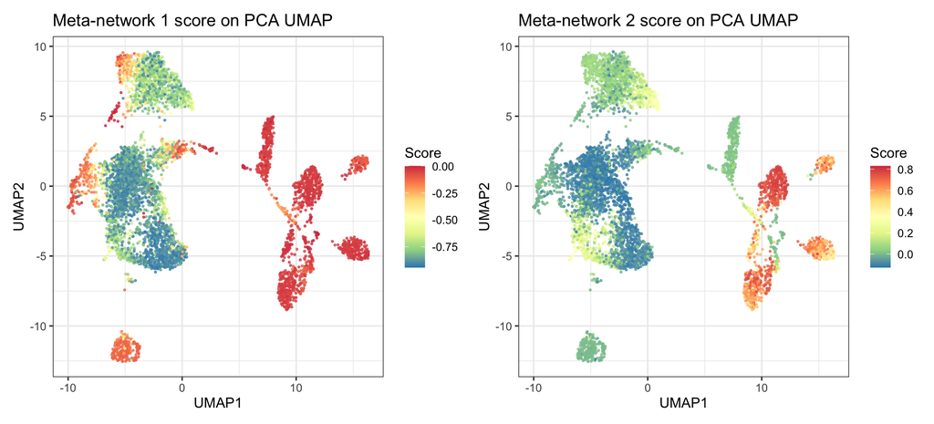

```r
umap <- reducedDim(cm, "UMAP")
umap_df <- as.data.frame(umap[match(rownames(meta_pcs), colnames(cm)), ,
                             drop = FALSE])
colnames(umap_df) <- c("UMAP1", "UMAP2")
umap_df$cell <- rownames(meta_pcs)
umap_df$NNet1 <- meta_pcs[, 1]
umap_df$NNet2 <- meta_pcs[, 2]

umap_score_plot <- function(score_col, title) {
    ggplot(umap_df, aes(UMAP1, UMAP2, colour = .data[[score_col]])) +
        geom_point(size = 0.5, alpha = 0.75) +
        scale_colour_distiller(palette = "Spectral", direction = -1) +
        labs(title = title, colour = "Score") +
        theme_bw(base_size = 12)
}

umap_score_plot("NNet1", "Meta-network 1 score on PCA UMAP") |
    umap_score_plot("NNet2", "Meta-network 2 score on PCA UMAP")
```

## 7 Pick the Maturation Meta-network

Each meta-network has a cell score. We correlate each score with `pt_phi_score`. The paper notes that the meta-networks are ordered: meta-network 1 is the strongest recurring co-expression pattern in the ensemble, and meta-network 2 is the next strongest pattern. We therefore show both, and use the correlation table to interpret which one tracks maturation most closely.

```r
safe_cor <- function(x, y) {
    sx <- stats::sd(x, na.rm = TRUE)
    sy <- stats::sd(y, na.rm = TRUE)
    if (is.na(sx) || is.na(sy) || sx == 0 || sy == 0) {
        return(NA_real_)
    }
    stats::cor(x, y, use = "complete.obs", method = "spearman")
}

cor_tbl <- tibble(
    meta_network = seq_len(ncol(meta_pcs)),
    spearman_cor = apply(meta_pcs, 2, safe_cor, y = seu$pt_phi_score)
) |>
    mutate(abs_cor = abs(spearman_cor)) |>
    arrange(desc(abs_cor))

cor_tbl
```

| meta_network | spearman_cor | abs_cor |
| --- | --- | --- |
| 1 | 7.241879e-01 | 7.241879e-01 |
| 2 | 6.091882e-01 | 6.091882e-01 |
| 4 | -1.754289e-01 | 1.754289e-01 |
| 3 | -1.390068e-01 | 1.390068e-01 |
| 10 | -1.104991e-01 | 1.104991e-01 |
| 21 | -9.201582e-02 | 9.201582e-02 |
| 6 | -9.200319e-02 | 9.200319e-02 |
| 14 | -9.197939e-02 | 9.197939e-02 |
| 22 | 9.144314e-02 | 9.144314e-02 |
| 24 | -8.730288e-02 | 8.730288e-02 |

[output cut: 90 more lines]

```r
maturation_idx <- cor_tbl$meta_network[1]
cat("Meta-network most associated with maturation:", maturation_idx, "\n")
```

```
## Meta-network most associated with maturation: 1
```

This selection is intentionally data-driven. We are not deciding which network “looks right”; we are asking which recurring co-expression pattern tracks the continuous maturation score most strongly.

## 8 Meta-network Adjacency Matrices

Figure 3C in the paper shows the weighted adjacency matrices behind the first two meta-networks. Each heatmap is a TF-by-target view of a meta-network: bright tiles mark TF-target pairs with strong aggregated co-expression in that recurrent network pattern.

Because our workshop run keeps only 10 requested target genes, and five survive NeighbourNet’s target-prior and expression filters in this data, we show all retained targets and the top 10 TFs for each meta-network.

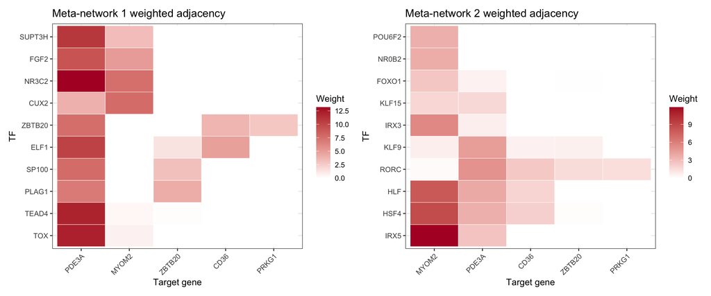

```r
plot_adjacency <- function(i, n_tf = 10, n_target = 10) {
    mat <- Seurat::Misc(seu, "NNet.mod")$meta.network$meta.network[, , i]

    target_score <- Matrix::rowSums(abs(mat))
    tf_score <- Matrix::colSums(abs(mat))

    targets <- names(sort(target_score, decreasing = TRUE))[
        seq_len(min(n_target, length(target_score)))
    ]
    tfs <- names(sort(tf_score, decreasing = TRUE))[
        seq_len(min(n_tf, length(tf_score)))
    ]

    plot_mat <- t(mat[targets, tfs, drop = FALSE])

    if (nrow(plot_mat) > 1) {
        plot_mat <- plot_mat[hclust(dist(plot_mat))$order, , drop = FALSE]
    }
    if (ncol(plot_mat) > 1) {
        plot_mat <- plot_mat[, hclust(dist(t(plot_mat)))$order, drop = FALSE]
    }

    adj_df <- as.data.frame(as.table(plot_mat))
    colnames(adj_df) <- c("TF", "Target", "weight")

    ggplot(adj_df, aes(Target, TF, fill = weight)) +
        geom_tile(colour = "white", linewidth = 0.2) +
        scale_fill_gradient(low = "white", high = "#B2182B") +
        labs(title = paste("Meta-network", i, "weighted adjacency"),
             x = "Target gene", y = "TF", fill = "Weight") +
        theme_bw(base_size = 11) +
        theme(axis.text.x = element_text(angle = 45, hjust = 1))
}

plot_adjacency(1) | plot_adjacency(2)
```

## 9 Visualise the First Two Meta-networks

NeighbourNet’s network plot uses prior knowledge to arrange the figure in layers. The radial layout helps interpretation, but it should not be read as experimental proof of directionality.

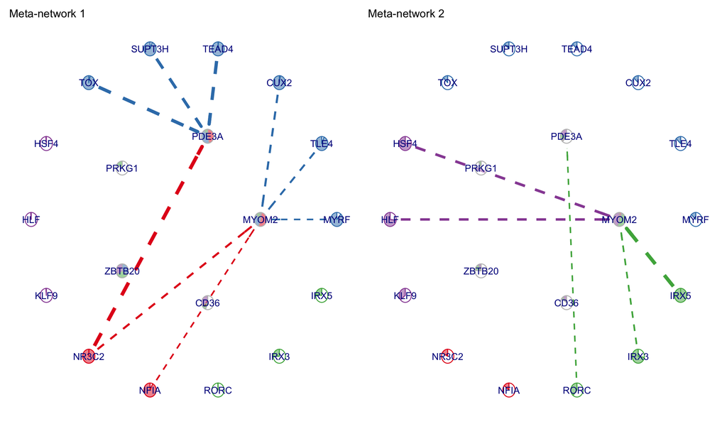

```r
central_genes <- select.central.genes(
    seu,
    n.net = min(2, n_meta_networks),
    n.per.component = 4,
    k = 2
)
seu <- prepare.visualise(seu, central.genes = central_genes, n.clu = 4)

edge_cutoff <- function(p_mat) {
    mean(apply(p_mat, 1, max, na.rm = TRUE), na.rm = TRUE)
}

plot_meta_network <- function(i) {
    meta_p <- Seurat::Misc(seu, "NNet.mod")$meta.network$p.val[, , i]
    visualise.network(
        seu,
        i = i,
        meta.network = TRUE,
        cutoff = edge_cutoff(meta_p),
        radius = c(0.4, 0.7, 0.85, 1),
        pie.radius = 0.04,
        text.size = 4
    ) +
        labs(title = paste("Meta-network", i))
}

plot_meta_network(1) | plot_meta_network(2)
```

Read these as compact hypothesis generators. The target clusters tell us which maturation-associated genes share TF co-expression structure. The TFs and receptor context suggest plausible upstream biology. Follow-up experiments or perturbation data would be needed before calling any edge causal regulation.

## 10 Representative Cell-specific Networks

A meta-network is an aggregate over many cell-specific networks. To make that connection concrete, we pick one representative cell for each of the first two meta-networks: the cell with the largest score on that meta-network. These plots are slices of the original cell-specific network ensemble, not averages.

```r
shown_meta_networks <- seq_len(min(2, ncol(meta_pcs)))
rep_tbl <- tibble(
    meta_network = shown_meta_networks,
    cell_idx = vapply(shown_meta_networks, function(i) {
        which.max(meta_pcs[, i])
    }, integer(1))
) |>
    mutate(
        cell = rownames(meta_pcs)[cell_idx],
        meta_score = meta_pcs[cbind(cell_idx, meta_network)],
        group = seu$group[match(cell, colnames(seu))],
        pt_phi_score = seu$pt_phi_score[match(cell, colnames(seu))]
    )

rep_tbl
```

| meta_network | cell_idx | cell | meta_score | group | pt_phi_score |
| --- | --- | --- | --- | --- | --- |
| 1 | 5244 | TATTTCGAGGGAGAAT_a1 | 8.860176e-18 | adult | 0.4293677 |
| 2 | 4443 | GCAACCGAGTGGGAAA_y2 | 8.294486e-01 | young | 0.4877844 |

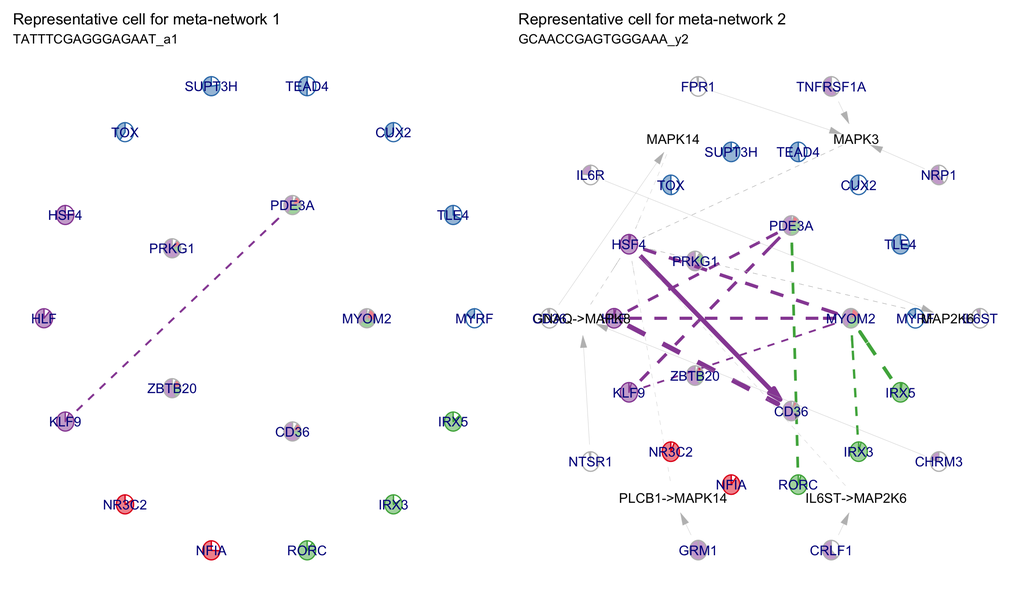

```r
plot_cell_network <- function(cell_idx, meta_idx, cell_name) {
    cell_p <- Seurat::Misc(seu, "NNet.mod")$p.val[, , cell_idx]
    visualise.network(
        seu,
        i = cell_idx,
        meta.network = FALSE,
        cutoff = edge_cutoff(cell_p),
        radius = c(0.4, 0.7, 0.85, 1),
        pie.radius = 0.04,
        text.size = 4
    ) +
        labs(title = paste("Representative cell for meta-network",
                           meta_idx),
             subtitle = cell_name)
}

cell_plots <- lapply(seq_len(nrow(rep_tbl)), function(i) {
    plot_cell_network(rep_tbl$cell_idx[i],
                      rep_tbl$meta_network[i],
                      rep_tbl$cell[i])
})

wrap_plots(cell_plots, nrow = 1)
```

## 11 What We Are Not Running

NeighbourNet also includes `receptor.activity()`, which propagates cell-specific TF-target networks through the signalling prior to estimate receptor activity per cell. That is useful when the biological question is about upstream signalling pathways, but it would add another conceptual layer to this short workshop. For self-study, the NeighbourNet cell-cycle vignette shows the full receptor-activity workflow.

## 12 Handing Off

This module writes one cache:

- `results/07_seu_nnet_10targets.rds` — the cardiomyocyte Seurat object after `build.meta.network()`, including `@misc$NNet.mod` and the Module 7 target-gene selection metadata.

Because the cache is saved before visualisation, you can re-run the plots and tune the network layout without repeating the per-cell regressions.

## 13 Summary

- NeighbourNet builds **cell-specific co-expression networks**, not causal GRNs.
- We focused the network on maturation by selecting 10 target genes associated with the trajectory-free Φ-Space score `pt_phi_score`.
- Meta-networks summarise recurring co-expression programs across cells.
- Meta-networks 1 and 2 are the two strongest recurring network patterns; representative cell networks show noisy individual slices of the same ensemble.
- The network plots are hypothesis generators: useful, structured, and biologically suggestive, but not causal proof.